# Case Study 3: CPTO 🧐🧐🧐

# I. Load and check data

Data summary

| Name | data_semi |
| --- | --- |
| Number of rows | 35763 |
| Number of columns | 28 |
| _______________________ |  |
| Column type frequency: |  |
| factor | 16 |
| numeric | 12 |
| ________________________ |  |
| Group variables | None |

**Variable type: factor**

| skim_variable | n_missing | complete_rate | ordered | n_unique | top_counts |
| --- | --- | --- | --- | --- | --- |
| WORKSHOP | 0 | 1.00 | FALSE | 8 | wor: 10653, wor: 5408, wor: 5091, wor: 4452 |
| EQUIPMENT_GROUP | 0 | 1.00 | FALSE | 90 | equ: 6402, equ: 3273, equ: 3207, equ: 2583 |
| EQUIPMENT_SUB_GROUP | 0 | 1.00 | FALSE | 233 | equ: 6402, equ: 3273, equ: 2246, equ: 1162 |
| EQUIPMENT | 0 | 1.00 | FALSE | 477 | equ: 487, equ: 445, equ: 418, equ: 364 |
| EQUIPMENT_HARDWARE | 1045 | 0.97 | FALSE | 91 | equ: 3172, equ: 2081, equ: 1568, equ: 1498 |
| CLUSTER_CINEMATICS | 0 | 1.00 | FALSE | 7 | SIN: 28960, DOU: 2493, FUR: 1258, EXT: 1015 |
| LOT | 0 | 1.00 | FALSE | 5057 | lot: 33, lot: 33, lot: 32, lot: 31 |
| PRODUCT | 0 | 1.00 | FALSE | 294 | pro: 9150, pro: 2531, pro: 2466, pro: 1130 |
| RETICLE | 29675 | 0.17 | FALSE | 1955 | ret: 626, ret: 68, ret: 43, ret: 43 |
| OPERATION | 0 | 1.00 | FALSE | 6078 | ope: 55, ope: 54, ope: 49, ope: 49 |
| LOT_RECIPE_GROUP | 162 | 1.00 | FALSE | 177 | lot: 3609, lot: 2511, lot: 2365, lot: 2180 |
| LOT_RECIPE | 0 | 1.00 | FALSE | 2458 | lot: 498, lot: 419, lot: 342, lot: 305 |
| TOOL_RECIPE | 9 | 1.00 | FALSE | 3077 | too: 498, too: 419, too: 403, too: 342 |
| JOB | 0 | 1.00 | FALSE | 33999 | job: 6, job: 6, job: 6, job: 6 |
| USED_PROCESS_MODULES | 14811 | 0.59 | FALSE | 229 | 01 : 2722, 01 : 1691, 01 : 1599, 01 : 1446 |
| ALARM_DURING_PROCESS | 0 | 1.00 | FALSE | 2 | N: 34424, Y: 1339 |

**Variable type: numeric**

| skim_variable | n_missing | complete_rate | mean | sd | p0 | p25 | p50 | p75 | p100 | hist |
| --- | --- | --- | --- | --- | --- | --- | --- | --- | --- | --- |
| WAFERS_COUNT | 0 | 1.00 | 24.16 | 3.54 | 1.00 | 25.00 | 25.00 | 25.00 | 25.00 | ▁▁▁▁▇ |
| OPERATION_START_TIME | 0 | 1.00 | 18220979.11 | 50278.42 | 18080955.00 | 18177549.50 | 18220206.00 | 18264421.50 | 18312745.00 | ▁▆▇▇▇ |
| PROCESS_START_TIME | 0 | 1.00 | 18221679.67 | 50200.15 | 18091172.00 | 18178254.50 | 18220848.00 | 18265015.00 | 18312873.00 | ▁▇▇▇▇ |
| PROCESS_END_TIME | 0 | 1.00 | 18224911.21 | 49982.79 | 18137960.00 | 18181457.50 | 18224233.00 | 18268148.00 | 18313184.00 | ▇▇▇▇▇ |
| OPERATION_END_TIME | 0 | 1.00 | 18225003.70 | 49979.04 | 18140405.00 | 18181538.50 | 18224384.00 | 18268276.50 | 18313194.00 | ▇▇▇▇▇ |
| OPERATION_START_DAY | 0 | 1.00 | 1.62 | 1.00 | 1.00 | 1.00 | 1.00 | 2.00 | 7.00 | ▇▁▁▁▁ |
| PROCESS_START_DAY | 0 | 1.00 | 1.60 | 0.94 | 1.00 | 1.00 | 1.00 | 2.00 | 7.00 | ▇▁▁▁▁ |
| PROCESS_END_DAY | 0 | 1.00 | 1.49 | 0.52 | 1.00 | 1.00 | 1.00 | 2.00 | 7.00 | ▇▁▁▁▁ |
| OPERATION_END_DAY | 0 | 1.00 | 1.49 | 0.50 | 1.00 | 1.00 | 1.00 | 2.00 | 2.00 | ▇▁▁▁▇ |
| USED_PROCESS_MODULES_COUNT | 14811 | 0.59 | 5.16 | 3.76 | 1.00 | 2.00 | 4.00 | 8.00 | 22.00 | ▇▂▃▁▁ |
| REAL_THROUGHPUT_IN_WAFERS_PER_HOUR | 0 | 1.00 | 126.74 | 109.96 | 0.38 | 39.36 | 99.36 | 192.86 | 3600.00 | ▇▁▁▁▁ |
| MODEL_THROUGHPUT_IN_WAFERS_PER_HOUR | 14476 | 0.60 | 148.56 | 107.85 | 4.08 | 65.59 | 126.49 | 205.25 | 514.29 | ▇▆▃▁▁ |

# II. How many equipments?

There are 477 equipements. We can then see the detail list of the equipment with their number of occurrences in decreasing order. For example : *N°1 equipment_0061____________487 occurrences* *N°2 equipment_0050____________445 occurrences* *N°3 equipment_0163____________418 occurrences* *N°4 equipment_0169____________364 occurrences, etc..*

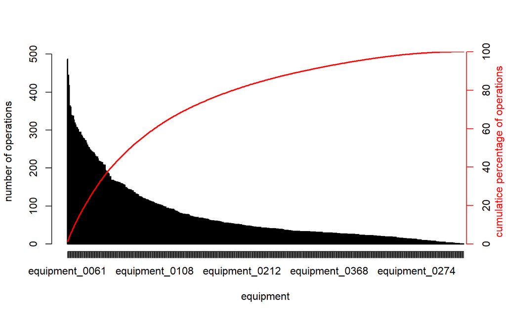

# III. Workload over time?

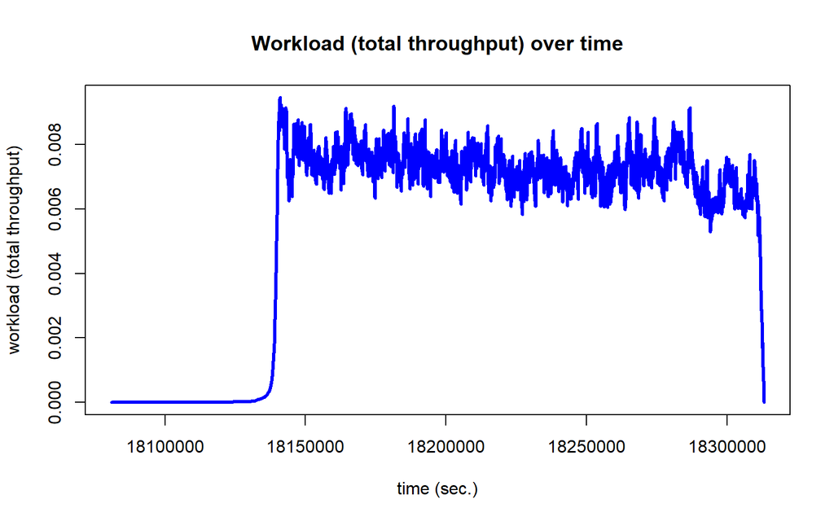

From time stamp Operation Start to Operation End, and the Real throughput, which provides the rate of production over time. However, it’s important to acknowledge that the ‘time-horizon where everything is known’ cannot be precisely determined from the data alone. While visual inspection of workload charts may suggest balance, it’s essential to recognize that trends may vary based on the dataset’s size and completeness.

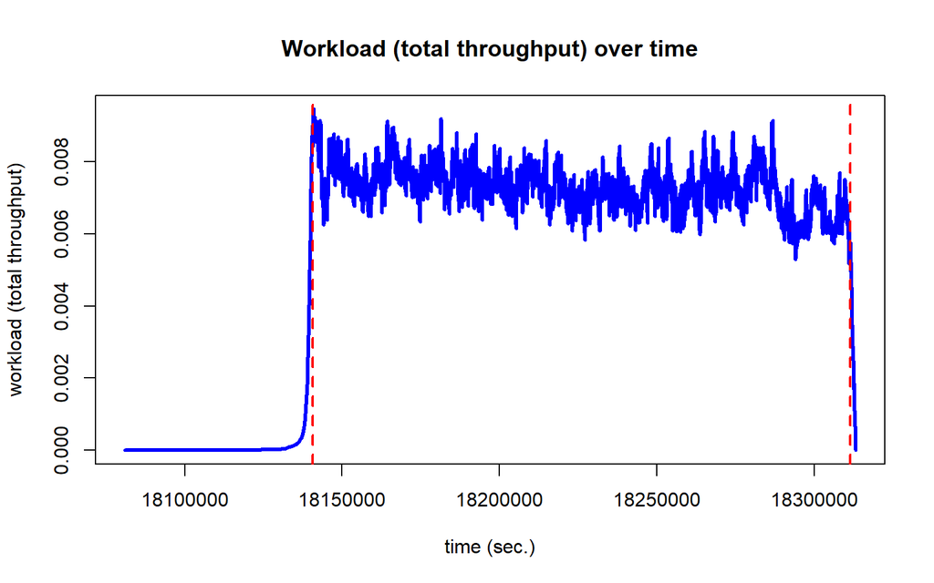

Zooming in may reveal apparent decreases, but these fluctuations could be attributed to the dataset’s limitations. With a larger dataset, such trends may dissipate, offering a clearer picture of workload dynamics.

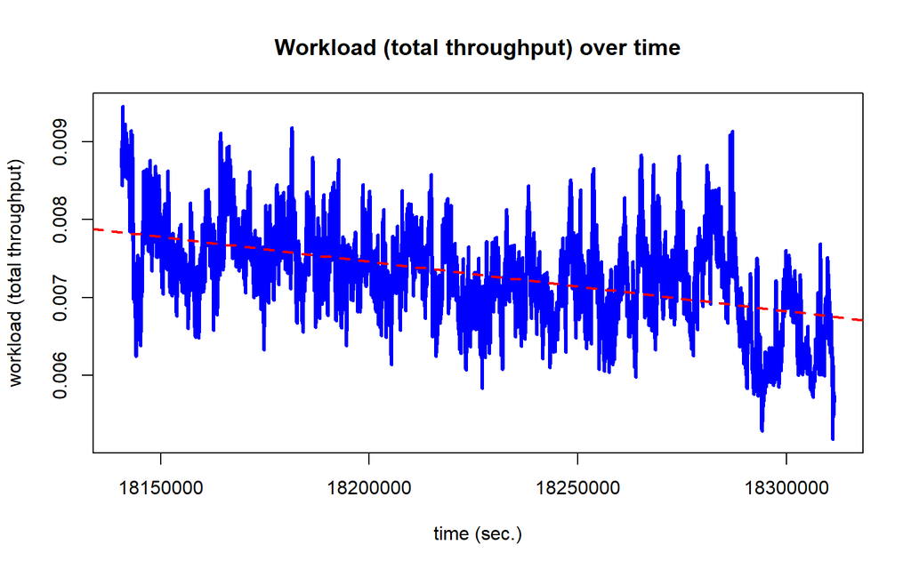

# IV. Lot wait a lot

By examining delays at specific points in time, we can determine if lots experience prolonged wait times before and after operations. Interestingly, our analysis reveals that lots tend to wait considerably longer before operations commence compared to the time spent waiting to complete them. This observation underscores the significance of pre-operation wait times, suggesting potential areas for optimization and efficiency enhancement in the production process.

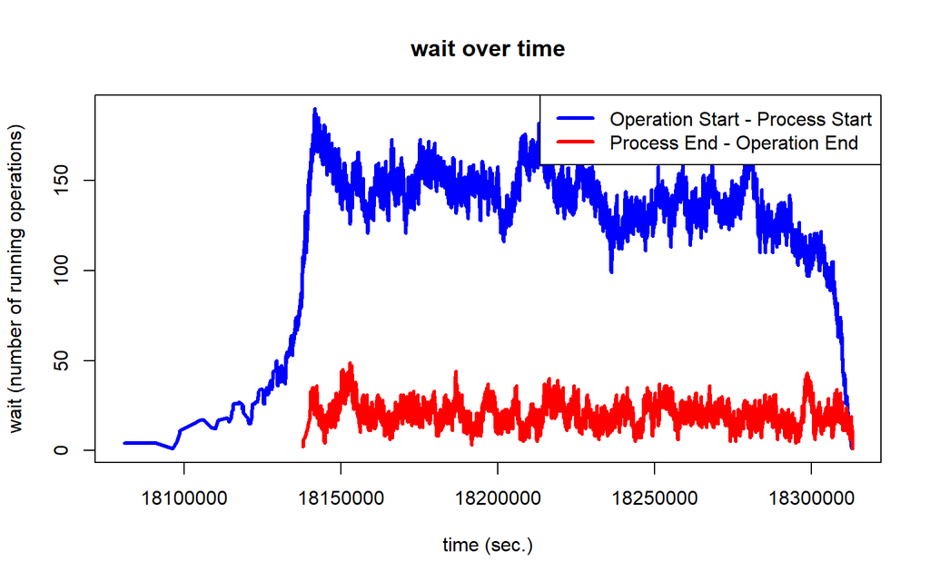

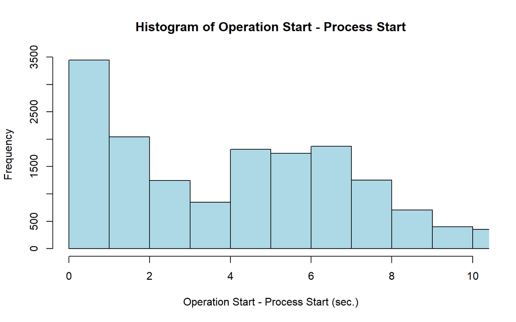

After examining whether lots experience significant wait times, it became evident that some lots consist of multiple steps, indicating a sequential production process. Surprisingly, the analysis revealed that the time spent waiting between each process step within a lot far exceeds the wait time before the first operation. The summary statistics further emphasize this observation, indicating that the median total wait time between process steps (Median: 74368 seconds) is substantially higher than the median wait time before the operation (Median: 3788 seconds). This highlights a critical area for improvement in our production workflow, suggesting a need to streamline and optimize the transition between process steps to reduce overall production lead times and enhance efficiency.

```r
summary(lot_gap_times$total_gap_time)
```

```
##    Min. 1st Qu.  Median    Mean 3rd Qu.    Max.
##     107   36278   74368   71572  105750  164166
```

```r
summary(lot_gap_times$total_gap_time_start)
```

```
##    Min. 1st Qu.  Median    Mean 3rd Qu.    Max.
##       2    1244    3788    5562    8145   41164
```

# V. Rework

After identifying rework instances within the dataset as lots with identical operations, it was found that out of 5057 lots, only 67 lots required rework. This equates to approximately 1.32% of lots, suggesting a relatively low incidence of rework within the production process.

```
## # A tibble: 67 × 3
## # Groups:   LOT [67]
##    LOT         ori_time rework_time
##    <fct>          <dbl>       <dbl>
##  1 lot_0000241     9174        3150
##  2 lot_0000341     2360        2150
##  3 lot_0000943     4080        4072
##  4 lot_0001189     4263        3084
##  5 lot_0001636     5130        7607
##  6 lot_0001849     1468        9180
##  7 lot_0002005     1837        5885
##  8 lot_0002146     4139        4148
##  9 lot_0002530    39712        7414
## 10 lot_0002852     3277        7974
## # ℹ 57 more rows
```

# VI. EQUIPMENT_SUB_GROUP

The stability of EQUIPMENT_SUB_GROUP can be assessed by examining whether each equipment belongs to only one subgroup. In this analysis, it was found that each equipment indeed corresponds to only one subgroup, indicating stability within the EQUIPMENT_SUB_GROUP classification. This observation suggests consistency and reliability in equipment allocation, which is crucial for maintaining operational efficiency and streamlining production processes

```
## # A tibble: 477 × 2
##    EQUIPMENT      distinct_sub_group_count
##    <fct>                             <int>
##  1 equipment_0001                        1
##  2 equipment_0002                        1
##  3 equipment_0003                        1
##  4 equipment_0004                        1
##  5 equipment_0005                        1
##  6 equipment_0006                        1
##  7 equipment_0007                        1
##  8 equipment_0008                        1
##  9 equipment_0009                        1
## 10 equipment_0010                        1
## # ℹ 467 more rows
```

The coherence of EQUIPMENT_SUB_GROUP can be evaluated by assessing whether equipment within the same subgroup perform similar activities or have similar operational capabilities.

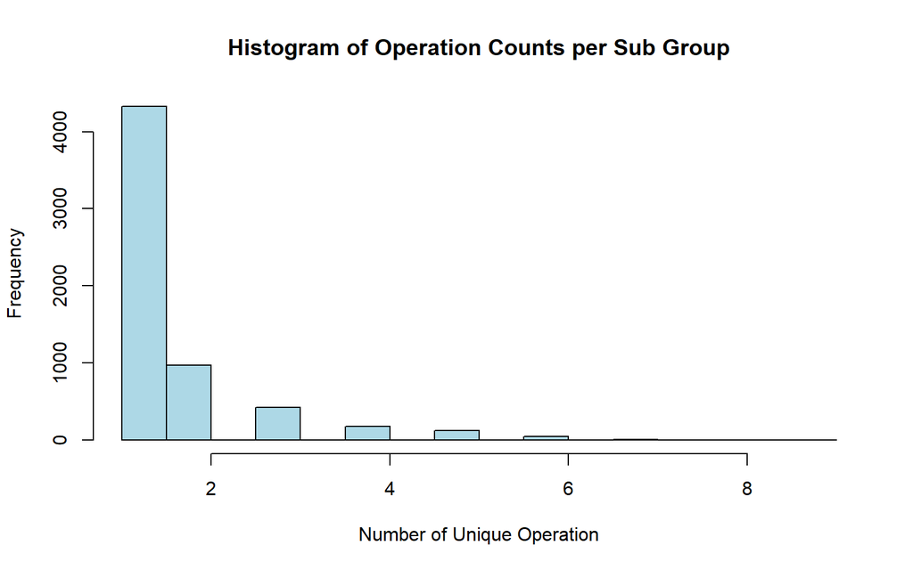

```
## # A tibble: 16 × 3
##    OPERATION        subgroup_list                                 subgroup_count
##    <fct>            <chr>                                                  <int>
##  1 operation_000148 equipment_sub_group_0012, equipment_sub_grou…              7
##  2 operation_000197 equipment_sub_group_0012, equipment_sub_grou…              7
##  3 operation_000274 equipment_sub_group_0006, equipment_sub_grou…              7
##  4 operation_000297 equipment_sub_group_0006, equipment_sub_grou…              7
##  5 operation_000312 equipment_sub_group_0012, equipment_sub_grou…              8
##  6 operation_000391 equipment_sub_group_0006, equipment_sub_grou…              9
##  7 operation_000498 equipment_sub_group_0062, equipment_sub_grou…              7
##  8 operation_000504 equipment_sub_group_0006, equipment_sub_grou…              7
##  9 operation_000568 equipment_sub_group_0006, equipment_sub_grou…              9
## 10 operation_000588 equipment_sub_group_0006, equipment_sub_grou…              7
## 11 operation_000630 equipment_sub_group_0006, equipment_sub_grou…              7
## 12 operation_000647 equipment_sub_group_0006, equipment_sub_grou…              8
## 13 operation_001223 equipment_sub_group_0084, equipment_sub_grou…              8
## 14 operation_001414 equipment_sub_group_0012, equipment_sub_grou…              7
## 15 operation_001480 equipment_sub_group_0010, equipment_sub_grou…              7
## 16 operation_001999 equipment_sub_group_0006, equipment_sub_grou…              7
```

```
## Summary Statistics for equipment_count column:
```

```
## Minimum count: 1
```

```
## Maximum count: 9
```

In this analysis, it was observed that certain equipment subgroups were associated with a diverse range of operations, while others were linked to specific operations performed by a unique set of equipment. This lack of coherence suggests inconsistencies in equipment functionality within certain subgroups, potentially leading to operational inefficiencies and increased complexity in resource management

There are 724 operations which can do at least one same operation. So the listed sub-groups are coherent. cuz they can do as least 1 same operation. Mean these sub group can do the same thing.

```
## # A tibble: 724 × 1
##    subgroup_list
##    <chr>
##  1 equipment_sub_group_0004, equipment_sub_group_0063
##  2 equipment_sub_group_0006, equipment_sub_group_0069, equipment_sub_group_0096…
##  3 equipment_sub_group_0007, equipment_sub_group_0043
##  4 equipment_sub_group_0089, equipment_sub_group_0070
##  5 equipment_sub_group_0006, equipment_sub_group_0032, equipment_sub_group_0044…
##  6 equipment_sub_group_0012, equipment_sub_group_0025, equipment_sub_group_0033…
##  7 equipment_sub_group_0009, equipment_sub_group_0083
##  8 equipment_sub_group_0039, equipment_sub_group_0046, equipment_sub_group_0001
##  9 equipment_sub_group_0018, equipment_sub_group_0034, equipment_sub_group_0106
## 10 equipment_sub_group_0024, equipment_sub_group_0074
## # ℹ 714 more rows
```

Indeed, considering the short timeframe of the data, the observed stability and coherence may be somewhat skewed. Three days may not provide a comprehensive representation of equipment usage patterns and operational consistency over longer periods. Therefore, while the current analysis indicates stability and coherence within EQUIPMENT_SUB_GROUP, it’s essential to exercise caution and recognize the limitations of the dataset’s timeframe.

# VII. THROUGHPUT

```
## Model throughput Missing value 14476 over 35763 -
```

```
## Real throughput missing values  0 over 35763
```

To gauge the model’s accuracy, we employed the absolute error technique, comparing the predicted throughput with the real throughput.

```
## If we accept 10% different between model and real the perform of current model is 47.41 % count the NA value
```

We endeavored to enhance the model by exploring its relationship with time

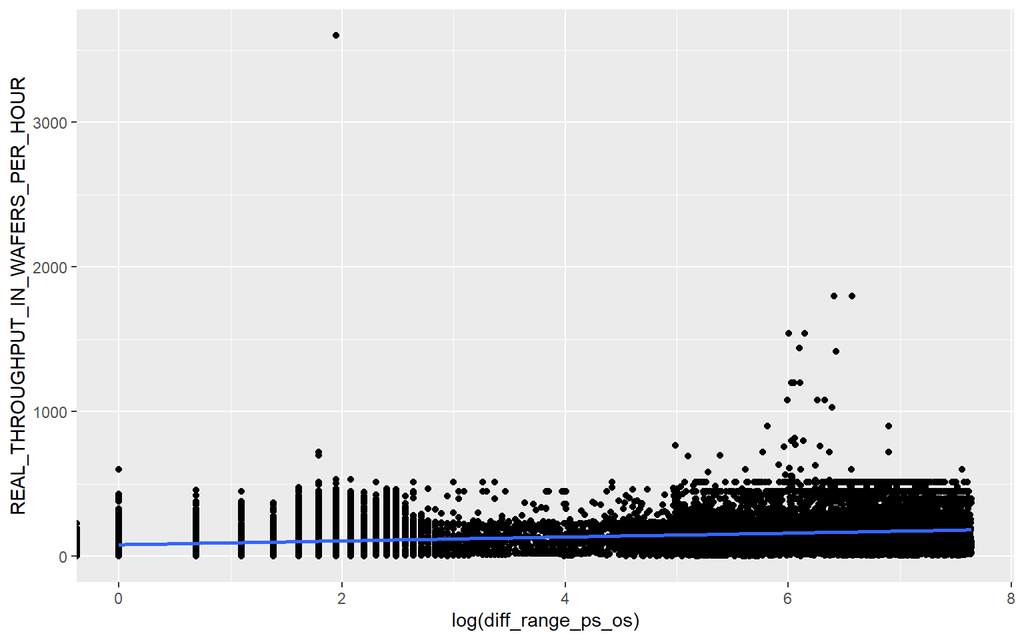

Our initial observation suggests a potential correlation: as the delay time between operation start and actual process start increases, there appears to be a corresponding rise in throughput. Conversely, a longer delay time between process end and operation end seems to correlate with lower throughput. However, these observations lack definitive evidence.

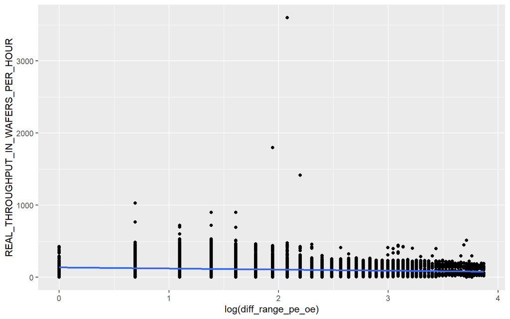

To gain deeper insights, we shifted our focus to the qualitative parameters, particularly the REAL_THROUGHPUT column, which represents observed equipment performance aggregated across multiple events. This perspective offers a more nuanced understanding of throughput dynamics.

After examining the NA values in the model_throughput column, we discovered that the majority of these missing values are associated with only 8 subgroups.

```
## [1] "equipment_sub_group_0001" "equipment_sub_group_0002"
## [3] "equipment_sub_group_0005" "equipment_sub_group_0011"
## [5] "equipment_sub_group_0016" "equipment_sub_group_0020"
## [7] "equipment_sub_group_0041" "equipment_sub_group_0188"
```

```
## Model throughput NA value total when we don't count Sub Group have all is NA value  168 over 21455
```

Out of a total of 233 subgroups, we found 14,476 NA values. However, upon removing these subgroups from consideration, we were left with only 168 NA values remaining.

This indicates that a significant portion of the missing data is concentrated within a small subset of subgroups, with only 8 out of the total 233 subgroups contributing to the majority of NA values. As a result, we can deduce that focusing on these specific subgroups, particularly when encountering new values, could help improve the completeness of the factory model by targeting the resolution of NA values within these subgroups.

To address the missing values in the model_throughput column for the 8 identified subgroups, we will create a dataset specifically tailored for training the model. This dataset will focus exclusively on the subgroups that have NA values in the model_throughput column.

```r
# List of target equipment subgroups
target_subgroups <- c(
  "equipment_sub_group_0001", "equipment_sub_group_0002",
  "equipment_sub_group_0005", "equipment_sub_group_0011",
  "equipment_sub_group_0016", "equipment_sub_group_0020",
  "equipment_sub_group_0041", "equipment_sub_group_0188"
)

# Create data_semi_model_na
data_semi_model_na <- data_semi[data_semi$EQUIPMENT_SUB_GROUP %in% target_subgroups, ]
```

We will select specific columns that are believed to have a significant impact on throughput, considering the definition of REAL_THROUGHPUT_IN_WAFERS_PER_HOUR, which represents the observed throughput of the equipment. Based on this definition, we will include the following columns:

Equipment: The specific equipment involved in the production process. Cluster: The cluster to which the equipment belongs, providing additional context. Product type: The type of product being manufactured, which may influence throughput. Alarm present: A binary indicator representing the presence of alarms or symptoms of events during production.

In this section, we aimed to enhance the predictive capabilities of our model for throughput estimation. We employed a generalized linear model (GLM) to predict throughput values based on selected features, including equipment, cluster, product type, and the presence of alarms or symptoms during production.

```
##
## Call:
## glm(formula = REAL_THROUGHPUT_IN_WAFERS_PER_HOUR ~ ., data = data_semi_train)
##
## Coefficients: (3 not defined because of singularities)
##                                  Estimate Std. Error t value Pr(>|t|)
## (Intercept)                     113.44294    4.42090  25.661  < 2e-16 ***
## EQUIPMENTequipment_0002         -15.35718    6.54606  -2.346 0.018989 *
## EQUIPMENTequipment_0004         -96.51768   17.62096  -5.477 4.39e-08 ***
## EQUIPMENTequipment_0007         -87.40824    9.46489  -9.235  < 2e-16 ***
## EQUIPMENTequipment_0008        -105.06392   12.28515  -8.552  < 2e-16 ***
## EQUIPMENTequipment_0009           7.97651    5.87441   1.358 0.174536
## EQUIPMENTequipment_0013         333.09784    5.89573  56.498  < 2e-16 ***
## EQUIPMENTequipment_0016         101.11250    5.20960  19.409  < 2e-16 ***
## EQUIPMENTequipment_0017         -96.10334   12.03790  -7.983 1.54e-15 ***
## EQUIPMENTequipment_0018         -61.11106    8.13537  -7.512 6.19e-14 ***
## EQUIPMENTequipment_0019         -65.05249    6.97180  -9.331  < 2e-16 ***
## EQUIPMENTequipment_0023         -78.62881    6.33544 -12.411  < 2e-16 ***
## EQUIPMENTequipment_0024         -55.04683    6.81378  -8.079 7.08e-16 ***
## EQUIPMENTequipment_0027         -60.02353    7.96520  -7.536 5.16e-14 ***
## EQUIPMENTequipment_0029         -88.81595   18.04900  -4.921 8.72e-07 ***
## EQUIPMENTequipment_0030         -26.65146    6.28177  -4.243 2.22e-05 ***
## EQUIPMENTequipment_0033         -65.34040    7.58379  -8.616  < 2e-16 ***
## EQUIPMENTequipment_0040         -87.48109    8.72868 -10.022  < 2e-16 ***
## EQUIPMENTequipment_0044         -22.34189    5.88253  -3.798 0.000146 ***
## EQUIPMENTequipment_0050         182.93433    4.88892  37.418  < 2e-16 ***
##  [ reached getOption("max.print") -- omitted 462 rows ]
## ---
## Signif. codes:  0 '***' 0.001 '**' 0.01 '*' 0.05 '.' 0.1 ' ' 1
##
## (Dispersion parameter for gaussian family taken to be 2741.546)
##
##     Null deviance: 168720577  on 14307  degrees of freedom
## Residual deviance:  37912833  on 13829  degrees of freedom
## AIC: 154343
##
## Number of Fisher Scoring iterations: 2
```

After training the model, we utilized it to generate predictions for throughput values in our dataset.

```
## # A tibble: 14,308 × 3
##    REAL_THROUGHPUT_IN_WAFERS_PER_HOUR PREDICTED_THROUGHPUT ABSOLUTE_ERR_NEW
##                                 <dbl>                <dbl>            <dbl>
##  1                               94.8                 102.             0.08
##  2                               57.4                 104.             0.82
##  3                               93.1                 115.             0.24
##  4                              183.                  115.             0.37
##  5                               70.2                 102.             0.45
##  6                               55.6                 106.             0.9
##  7                               87.9                 104.             0.19
##  8                              110.                  104.             0.05
##  9                              140.                  104.             0.26
## 10                              150                   104.             0.3
## # ℹ 14,298 more rows
```

```
## If we accept 10% different between model and real the number accept of current model is 4197 over 14308
```

```
## So if we accept 10% different between model and real the number accept of current model + model provided by factory is 59.15 %
```

Subsequently, we calculated the absolute error between the predicted and real throughput values, considering the relative difference. Our analysis revealed that, under the criterion of accepting a 10% difference between model and real throughput values, our model achieved a favorable acceptance rate. Specifically, our model accounted for approximately 59.15% of accepted values when combined with the factory-provided model, representing a notable improvement from the initial 47.41% acceptance rate achieved solely by the factory model.

# VIII. CBR MODEL FOR THROUGHPUT

Case-Based Reasoning (CBR) is a technique works by using a database of past cases and their solutions to find the most appropriate solution for a new problem.

1. Retrieval: In the retrieval phase, CBR searches the case base for similar past cases that are relevant to the current problem. It uses similarity metrics to measure the similarity between the new problem and past cases.
2. Reuse: Once similar cases are retrieved, CBR adapts the solutions from these past cases to fit the current problem. This adaptation process may involve modifying or combining solutions from multiple past cases to create a solution for the new problem.
3. Revision: After adapting the solution, CBR evaluates and refines it based on feedback from the user or the environment. This revision step ensures that the solution is appropriate and effective for the current problem.
4. Retain: Finally, the new solution and its associated problem description are stored in the case base, enriching the database for future problem-solving.